# Capture and Conquer: A Strategic Guide to Pokémon Based on Stats and Capture Rate

### Silhouette Score Method

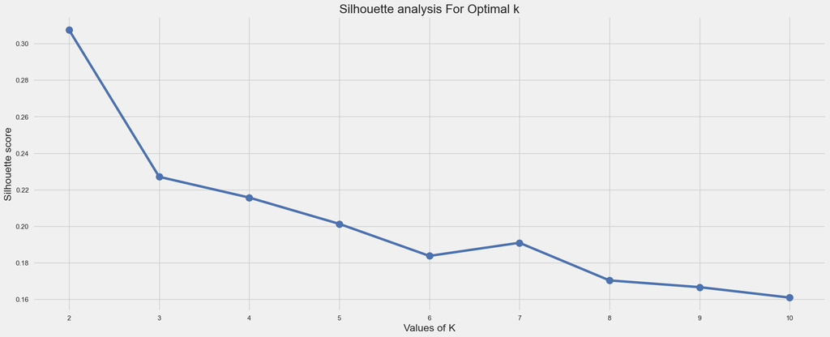

```
Optimal number of clusters: 2 with silhouette score average 0.307
```

```python
# range of cluster number for experiment

min_clusters = 2
max_clusters = 10

# Calculate silhouette score for different numbers of clusters

silhouette_scores = []

for n_clusters in range(min_clusters, max_clusters+1):
    kmeans = KMeans(n_clusters=n_clusters,  init='k-means++', max_iter=300, n_init=10, random_state = 42)
    cluster_labels = kmeans.fit_predict(scaled_features)
    silhouette_avg = silhouette_score(scaled_features, cluster_labels)
    silhouette_scores.append(silhouette_avg)

# Find the optimal number of clusters with the highest silhouette score
optimal_num_clusters = np.argmax(silhouette_scores) + min_clusters

range_n_clusters = range(2,11)

plt.plot(range_n_clusters, silhouette_scores, marker='o', markersize= 12, linestyle='-', color='b')
plt.xlabel('Values of K')
plt.ylabel('Silhouette score')
plt.title('Silhouette analysis For Optimal k')
plt.show()

print(f"Optimal number of clusters: {optimal_num_clusters} with silhouette score average {round(max(silhouette_scores),3)}")
```

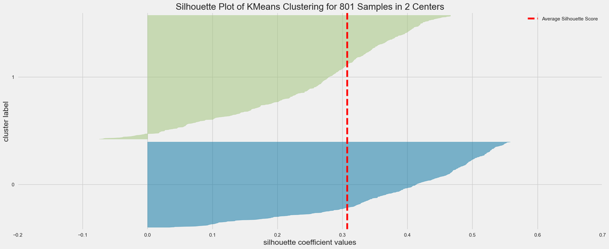

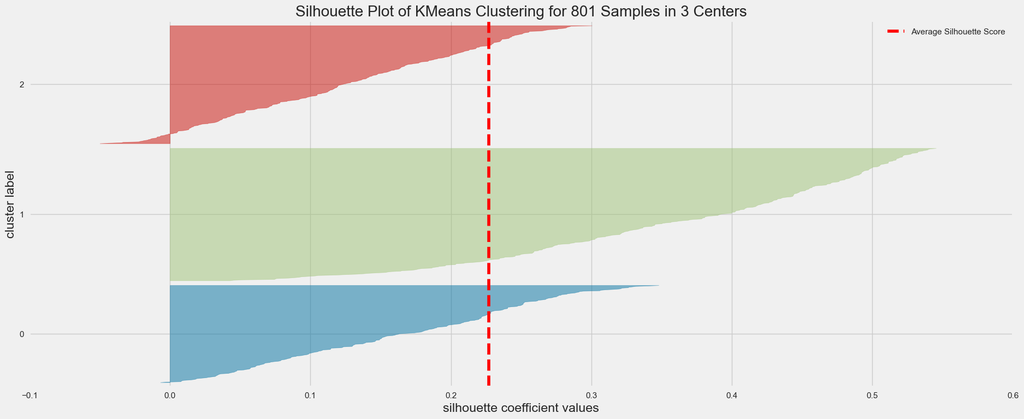

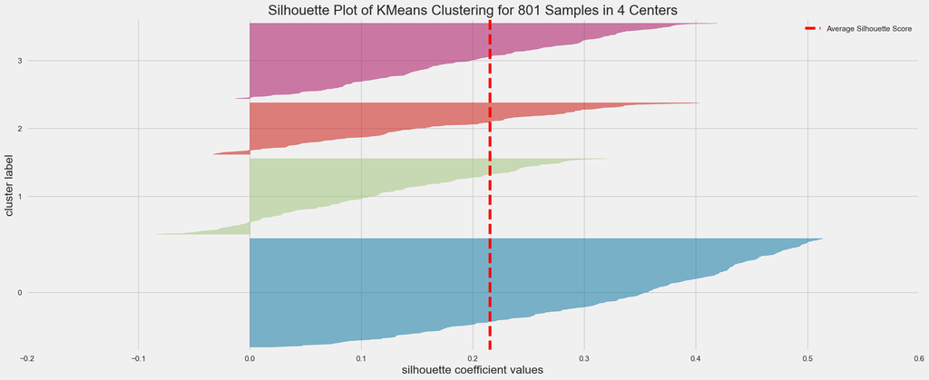

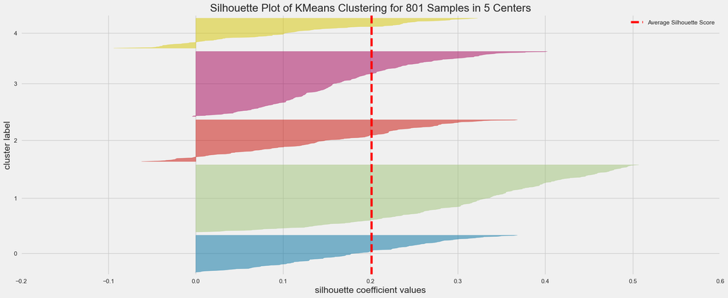

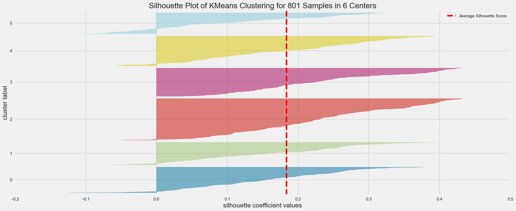

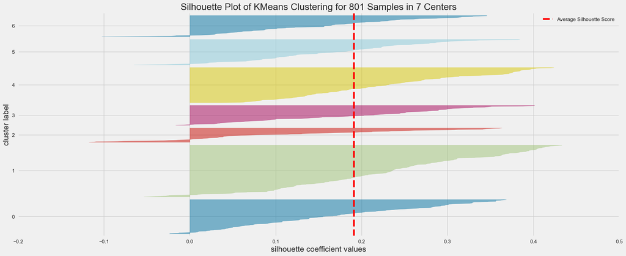

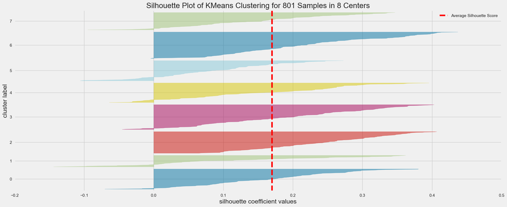

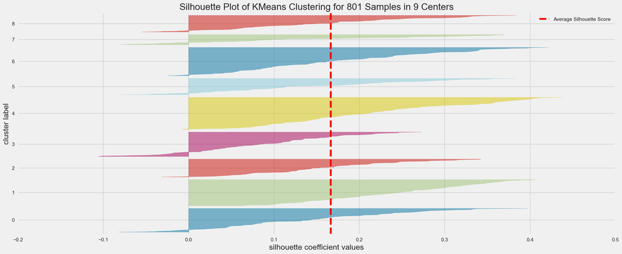

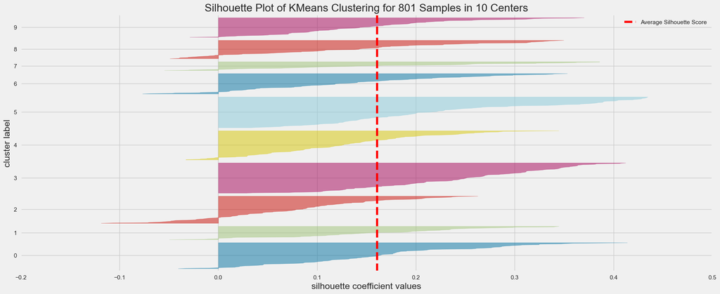

```python
# silhouette score results visualization

silhouette_scores = []

for n_clusters in range(2, 11):

    # Create KMeans instance for different number of clusters
    kmeans = KMeans(n_clusters=n_clusters, init='k-means++', n_init=10, max_iter=300, random_state=42)

    # Visualize silhouette score
    visualizer = SilhouetteVisualizer(kmeans, colors='yellowbrick')
    visualizer.fit(scaled_features)
    visualizer.show()

    # calculate average of silhouette score
    silhouette_scores.append(visualizer.silhouette_score_)
```

### Gap statistic

```python
# Function for calculate gap statistic to find cluster

def calculate_gap(data, k_max=10, n_refs=20):


    # Calculate inertia for the original data
    kmeans = KMeans(n_clusters=k_max, init='k-means++', n_init=10, max_iter=300, random_state=42)
    kmeans.fit(data)
    wcss_obs = kmeans.inertia_

    # Calculate inersia for reference (random) datasets
    wcss_refs = []
    for _ in range(n_refs):
        random_data = make_blobs(n_samples=len(data), random_state=42)[0]
        kmeans = KMeans(n_clusters=k_max, init='k-means++', n_init=10, max_iter=300, random_state=42)
        kmeans.fit(random_data)
        wcss_refs.append(kmeans.inertia_)

    # Calculate Gap Statistic
    gap = np.mean(np.log(wcss_refs)) - np.log(wcss_obs)

    # Calculate standard deviation of inersia for reference datasets
    sd_refs = np.std(np.log(wcss_refs))

    # Calculate standard error
    se = sd_refs / np.sqrt(n_refs)

    return gap, se
```

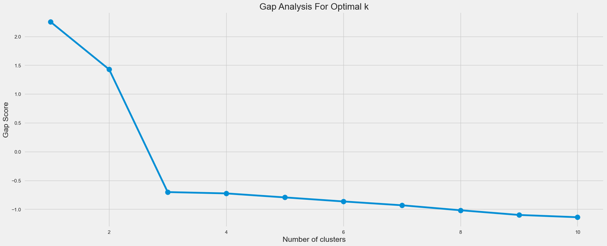

```python
# Plot the gap score

gap_values = []
errors = []
for k in range(1, 11):
  gap, se = calculate_gap(scaled_features, k_max=k)
  gap_values.append(gap)
  errors.append(se)

plt.figure()
plt.plot(range(1, 11), gap_values, marker='o', markersize= 12)
plt.xlabel("Number of clusters")
plt.ylabel("Gap Score")
plt.title('Gap Analysis For Optimal k')
plt.show()
```

```python
# Optimal cluster number with Gap Statistic method

optimalK = OptimalK(parallel_backend='joblib', random_state=42)
n_clusters = optimalK(scaled_features, cluster_array=np.arange(1, 11))
n_clusters
```

```
9
```

Based on gap analysis, the optimal number of cluster is 9.

As summary, the number of optimal clusters are different from Elbow, Silhouette score, and Gap Statistic method, with 4, 2, 9, respectively.

We will see the cluster effectiveness by comparing each methods through the aid of PCA visualization.

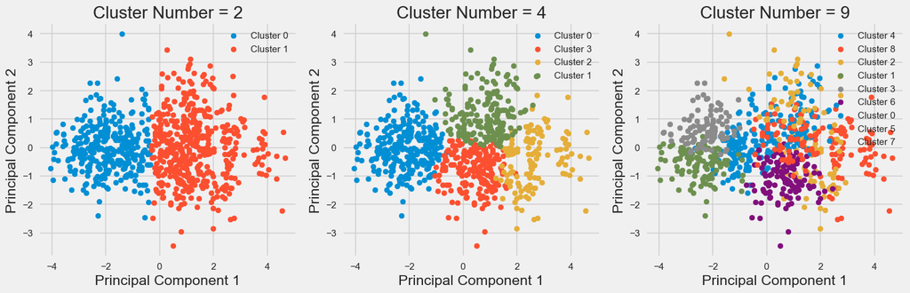

```python
cluster_values = [2, 4, 9]

# Create subplots
fig, axs = plt.subplots(1, len(cluster_values), figsize=(15, 5))

# Iterate over each number of clusters
for i, n_clusters in enumerate(cluster_values):
    # Initialize KMeans with specified number of clusters
    kmeans = KMeans(n_clusters=n_clusters, init='k-means++', max_iter=300, n_init=10, random_state=42)
    kmeans.fit(scaled_features)

    # Assign cluster labels to the original dataset
    pokemon_df['cluster'] = kmeans.labels_

    # Apply PCA for dimensionality reduction
    pca = PCA(n_components=2)
    principal_components = pca.fit_transform(scaled_features)

    # Create a DataFrame with the principal components and cluster labels
    pca_df = pd.DataFrame(data=principal_components, columns=['PC1', 'PC2'])
    pca_df['cluster'] = pokemon_df['cluster']  # Adding cluster labels

    # Plot clusters in 2D using PCA components
    for cluster in pca_df['cluster'].unique():
        cluster_data = pca_df[pca_df['cluster'] == cluster]
        axs[i].scatter(cluster_data['PC1'], cluster_data['PC2'], label=f'Cluster {cluster}')

    axs[i].set_title(f'Cluster Number = {n_clusters}')
    axs[i].set_xlabel('Principal Component 1')
    axs[i].set_ylabel('Principal Component 2')
    axs[i].legend()

plt.tight_layout()
plt.show()
```

We will not use the number of cluster recommendation from Gap Statistic (9), since the data distribution is heavily scattered and overlapped, implied that the data is not clustered effectively.

Both the number of clusters recommended by Elbow method (4) and Silhouette score method (2) are possible to use, because the data is categorized properly in each cluster.

The data distribution of cluster number = 2 is better than cluster number = 4, as we can see there are some data points that overlapped in cluster 2 and 3 in 4 clusters region.

There are pros and cons to determine whether we use 2 or 4 clusters. We will compare the interpretation using 2 and 4 clusters.

Let's see the median and data distribution for each clusters in 2 cluster first.

## Clustering Result using 2 Clusters

```python
kmeans = KMeans(n_clusters=2, init='k-means++', max_iter=300, n_init=10, random_state = 42)
kmeans.fit(scaled_features)

pokemon_df['cluster'] = kmeans.labels_
```

```python
# overview the median of stats and capture rate for each clusters

pokemon_df.groupby('cluster').agg({'hp': 'median',
                                   'attack': 'median',
                                   'defense': 'median',
                                   'sp_attack': 'median',
                                   'sp_defense': 'median',
                                   'speed': 'median',
                                   'capture_rate': ['median', 'count']})
```

| cluster | hp median | attack median | defense median | sp_attack median | sp_defense median | speed median | capture_rate median | capture_rate count |
| --- | --- | --- | --- | --- | --- | --- | --- | --- |
| 0 | 50.0 | 54.0 | 50.0 | 45.0 | 50.0 | 50.0 | 190.0 | 327 |
| 1 | 75.0 | 92.0 | 80.0 | 85.0 | 80.0 | 78.0 | 45.0 | 474 |

## Cluster Interpretation for 2 Cluster Types

The data is distributed properly into 2 categories, with distinct differences between them.

**Cluster 0 (Early Game Pokémon):**

Pokémon that belongs to this cluster have high capture rate, which is easy to catch. They also have relatively low values in all stats (around 50). Players do not need to worry much if they encountered Pokémon in this category, since they are not too strong. It is also worth trying to catch Pokémon, because they have extreme high of capture rate (median of 190). Players can use this advantage to complete their Pokémon entries.

Pokémon found in this category tend to be found in the first portion of the game where players can learn and explore the basic of battles without worrying of overwhelming challenge, usually in more common areas.

**Cluster 1 (Late Game Pokémon):**

Pokémon that belongs to this cluster have low capture rate (median of 45), indicating that they are extremely difficult to catch. This difficulty is related to their relatively powerful stats (around 80).

With the lowest capture rate, Pokémon in this cluster represent significant challenges, but offer substantial rewards. This encourages a deeper understanding of game mechanics, as they need to employ more advanced strategies. Their balance high stats across the board make them highly desirable for competitive play and endgame content.

Pokémon in this group usually found late in the game, such as in secret places or post-game areas, and even as secret or final boss.

## Clustering Result using 4 Clusters

```python
kmeans = KMeans(n_clusters=4, init='k-means++', max_iter=300, n_init=10, random_state = 42)
kmeans.fit(scaled_features)

pokemon_df['cluster'] = kmeans.labels_
```

```python
# overview the median of stats and capture rate for each clusters

pokemon_df.groupby('cluster').agg({'hp': 'median',
                                   'attack': 'median',
                                   'defense': 'median',
                                   'sp_attack': 'median',
                                   'sp_defense': 'median',
                                   'speed': 'median',
                                   'capture_rate': ['median', 'count']})
```

| cluster | hp median | attack median | defense median | sp_attack median | sp_defense median | speed median | capture_rate median | capture_rate count |
| --- | --- | --- | --- | --- | --- | --- | --- | --- |
| 0 | 48.0 | 52.0 | 48.0 | 45.0 | 48.0 | 48.0 | 190.0 | 279 |
| 1 | 75.0 | 85.0 | 95.0 | 65.0 | 80.0 | 50.0 | 55.0 | 195 |
| 2 | 85.0 | 104.0 | 90.0 | 120.0 | 100.0 | 95.0 | 45.0 | 133 |
| 3 | 70.0 | 81.5 | 63.0 | 77.0 | 69.0 | 90.0 | 60.0 | 194 |

## Cluster Interpretation for 4 Cluster Types

The data is distributed properly into 4 categories, with distinct differences between them.

**Cluster 0 (Early Game Pokémon):**

Pokémon that belongs to this cluster have high capture rate, which is easy to catch. They also have relatively low values in all stats (around 50). Players do not need to worry much if they encountered Pokémon in this category, since they are not too strong. It is also worth trying to catch Pokémon, because they have extreme high of capture rate (median of 190). Players can use this advantage to complete their Pokémon entries.

Pokémon found in this category tend to be found in the first portion of the game where players can learn and explore the basic of battles without worrying of overwhelming challenge, usually in more common areas.

**Cluster 1 (Middle Game - Defense Favored Pokémon):**

Pokémon that belongs to this cluster is stronger than Pokémon in cluster 0, indicated by their moderate capture rate (median of 55) and higher distribution of stats (around 75). Pokémon in this group have immense amount of attack (median of 85), special defense (median of 80), while having low speed (median of 50).

The most notable strength in this cluster is the extremely high defense (median of 95), making in this group ideal for players that prefer defensive, safe and slow approach in battle, since Pokémon this group can withstand more lethal blows from foes in long battles.

Pokémon in this group have higher attack than special attack, indicating that they are more suitable in normal attack rather than magical attack in special attack.

Pokémon in this group usually found in the mid game, where players start to facing tougher opponents and need sturdier party composition.

**Cluster 2 (Late Game Pokémon):**

Pokémon that belongs to this cluster have low capture rate (median of 45), indicating that they are extremely difficult to catch. This difficulty is related to their relatively powerful stats (around 100).

With the lowest capture rate, Pokémon in this cluster represent significant challenges, but offer substantial rewards. This encourages a deeper understanding of game mechanics, as they need to employ more advanced strategies. Their balance high stats across the board make them highly desirable for competitive play and endgame content.

Pokémon in this group usually found late in the game, such as in secret places or post-game areas, and even as secret or final boss.

**Cluster 3 (Middle Game - Speed Favored Pokémon):**

Pokémon that belongs to this cluster is also stronger than Pokémon in cluster 0, indicated by their moderate capture rate (median of 60) and higher distribution of stats (around 75). Pokémon in this group have extreme amount of speed (median of 90) and special attack (median of 77), while having low defense (median of 63) and special defense (median of 69).

Pokémon in this group may be suitable party for players that prefer aggressive, fast and risky approach in battle. Their lower defenses make them glass cannons, relying on quick strikes to win battles.

Pokémon in this group usually found in the mid game, where players start to facing tougher opponents and need nimbler party composition.

Both cluster 1 and 3 are categorized as middle game Pokémon, since they share similar overall stats. However, cluster 1 and 3 offered distinct playstyles for players. Players can choose Pokémon in cluster 3 if they prefer Pokémon with high agility, or Pokémon in cluster 1 if they prefer Pokémon with high durability.

## Summary

Both 2 and 4 clusters can be used by their own pros and cons.

The use of 2 clusters provides clear and simple interpretation in each clusters, as players can easily categorized them as 'Weak' Pokémon and 'Strong' Pokémon. However, using this approach may lead to oversimplicity, as players cannot identify 'Moderate' Pokémon between Weak and Strong Pokémon. This can lead to steep difficulty curves when players in the middle of transition from early to late game. We can use 2 clusters approach as an alternative if we prefer simplicity in Pokémon cluster.

The use of 4 clusters provides more information to players, which capable to tell more specific characteristics of Pokémon in each group. By using this approach, players can be better at strategize which Pokémon that is suitable for their playstyle.

Additionally, we have two more categories of Pokémon that belongs to middle game in 4 clusters type, as representation of 'Moderate' Pokémon. This options are not available if we use 2 clusters type approach.

Personally, I choose 4 clusters approach since this can give more valuable insights to players instead of just classifying Pokémon as weak and strong. In this approach, players can also consider which Pokémon is worth trying to catch, based on their playstyle preferences.

## Assign 4 Clusters Type Result to Original Dataset

```python
df['cluster'] = kmeans.labels_
```

```python
# add pokedex number and name for easier readibility
# selecting only clustered features for better clarity

selected_features = ['pokedex_number', 'name', 'hp', 'attack', 'defense', 'sp_attack', 'sp_defense', 'speed', 'capture_rate', 'cluster']
selected_df = df[selected_features]

# Define cluster names instead of cluster number for better interpretation

cluster_names = {
    0: 'Early Game',
    1: '(Durable) Middle Game',
    2: 'Late Game',
    3: '(Agile) Middle Game'
}

# Replace cluster labels with descriptive cluster names

selected_df = selected_df.copy()
selected_df['cluster'] = selected_df['cluster'].map(cluster_names)

# show cluster samples for the first 20 Pokémon as an example

selected_df.sample(20, random_state=42)
```

|  | pokedex_number | name | hp | attack | defense | sp_attack | sp_defense | speed | capture_rate | cluster |
| --- | --- | --- | --- | --- | --- | --- | --- | --- | --- | --- |
| 697 | 698 | Amaura | 77 | 59 | 50 | 67 | 63 | 46 | 45 | (Agile) Middle Game |
| 668 | 669 | Flabébé | 44 | 38 | 39 | 61 | 79 | 42 | 225 | Early Game |
| 63 | 64 | Kadabra | 40 | 35 | 30 | 120 | 70 | 105 | 100 | (Agile) Middle Game |
| 534 | 535 | Tympole | 50 | 50 | 40 | 50 | 40 | 64 | 255 | Early Game |
| 66 | 67 | Machoke | 80 | 100 | 70 | 50 | 60 | 45 | 90 | (Durable) Middle Game |
| 622 | 623 | Golurk | 89 | 124 | 80 | 55 | 80 | 55 | 90 | (Durable) Middle Game |
| 346 | 347 | Anorith | 45 | 95 | 50 | 40 | 50 | 75 | 45 | (Agile) Middle Game |
| 490 | 491 | Darkrai | 70 | 90 | 90 | 135 | 90 | 125 | 3 | Late Game |
| 557 | 558 | Crustle | 70 | 105 | 125 | 65 | 75 | 45 | 75 | (Durable) Middle Game |
| 456 | 457 | Lumineon | 69 | 69 | 76 | 69 | 86 | 91 | 75 | (Agile) Middle Game |
| 65 | 66 | Machop | 70 | 80 | 50 | 35 | 35 | 35 | 180 | Early Game |
| 286 | 287 | Slakoth | 60 | 60 | 60 | 35 | 35 | 30 | 255 | Early Game |
| 636 | 637 | Volcarona | 85 | 60 | 65 | 135 | 105 | 100 | 15 | Late Game |
| 67 | 68 | Machamp | 90 | 130 | 80 | 65 | 85 | 55 | 45 | (Durable) Middle Game |
| 327 | 328 | Trapinch | 45 | 100 | 45 | 45 | 45 | 10 | 255 | Early Game |
| 395 | 396 | Starly | 40 | 55 | 30 | 30 | 30 | 60 | 255 | Early Game |
| 244 | 245 | Suicune | 100 | 75 | 115 | 90 | 115 | 85 | 3 | Late Game |
| 377 | 378 | Regice | 80 | 50 | 100 | 100 | 200 | 50 | 3 | (Durable) Middle Game |
| 611 | 612 | Haxorus | 76 | 147 | 90 | 60 | 70 | 97 | 45 | (Agile) Middle Game |
| 527 | 528 | Swoobat | 67 | 57 | 55 | 77 | 55 | 114 | 45 | (Agile) Middle Game |

## Checking Cluster Assignment

To check whether clustering is properly done, we will inspect the cluster for Pikachu and Raichu as an example. Pikachu is one of the initial Pokémon, while Raichu is the Pokémon evolution from Pikachu. Because Raichu is the evolution form from Pikachu, Raichu should have assigned in higher cluster than Pikachu, as Raichu has overall better stats.

```python
selected_df[selected_df['name'] == 'Pikachu']
```

|  | pokedex_number | name | hp | attack | defense | sp_attack | sp_defense | speed | capture_rate | cluster |
| --- | --- | --- | --- | --- | --- | --- | --- | --- | --- | --- |
| 24 | 25 | Pikachu | 35 | 55 | 40 | 50 | 50 | 90 | 190 | Early Game |

```python
selected_df[selected_df['name'] == 'Raichu']
```

|  | pokedex_number | name | hp | attack | defense | sp_attack | sp_defense | speed | capture_rate | cluster |
| --- | --- | --- | --- | --- | --- | --- | --- | --- | --- | --- |
| 25 | 26 | Raichu | 60 | 85 | 50 | 95 | 85 | 110 | 75 | (Agile) Middle Game |

Pikachu is clustered to cluster 0 (Early Game), which belonged to early game Pokémon. On the other hand, Raichu is in cluster 3 (Agile - Middle Game), which belonged to middle game Pokémon. Hence, Pokémon in the dataset have already clustered properly based on their stats and capture rate to each cluster.